# MSE 5740 Final Project Code

# Data Processing

## Load the data

```r
wine_data = read.csv("winequality-all.csv", header = T, na.strings = "?", stringsAsFactors = T)
wine_data$color <- factor(wine_data$color, levels=c(1, 0), labels=c('R', 'W'))

drop <- c("color")
wine_data = wine_data[,!(names(wine_data) %in% drop)]
```

## Capping

```r
library(scales)
wine_data$fixed.acidity <- squish(wine_data$fixed.acidity, quantile(wine_data$fixed_acidity, c(.05, .95)))

wd_capped <- wine_data

varlist <- names(wine_data)
# varlist <- varlist[-length(varlist)]

for (i in varlist) {
    var <- eval(parse(text = paste0("wine_data$", i)))
    var <- squish(var, quantile(var, c(.05, .95)))
}


wd_capped$fixed.acidity <- squish(wd_capped$fixed.acidity, quantile(wd_capped$fixed_acidity, c(.05, .95)))
wd_capped$volatile.acidity <- squish(wd_capped$volatile.acidity, quantile(wd_capped$volatile.acidity, c(.05, .95)))
wd_capped$citric.acid<- squish(wd_capped$citric.acid, quantile(wd_capped$citric.acid, c(.05, .95)))
wd_capped$residual.sugar <- squish(wd_capped$residual.sugar, quantile(wd_capped$residual.sugar, c(.05, .95)))
wd_capped$chlorides <- squish(wd_capped$chlorides, quantile(wd_capped$chlorides, c(.05, .95)))
wd_capped$free.sulfur.dioxide <- squish(wd_capped$free.sulfur.dioxide, quantile(wd_capped$free.sulfur.dioxide, c(.05, .95)))
wd_capped$total.sulfur.dioxide <- squish(wd_capped$total.sulfur.dioxide, quantile(wd_capped$total.sulfur.dioxide, c(.05, .95)))
wd_capped$density <- squish(wd_capped$density, quantile(wd_capped$density, c(.05, .95)))
wd_capped$pH <- squish(wd_capped$pH, quantile(wd_capped$pH, c(.05, .95)))
wd_capped$sulphates <- squish(wd_capped$sulphates, quantile(wd_capped$sulphates, c(.05, .95)))
wd_capped$alcohol <- squish(wd_capped$alcohol, quantile(wd_capped$alcohol, c(.05, .95)))
wd_capped$quality <- squish(wd_capped$quality, quantile(wd_capped$quality, c(.05, .95)))

# We compare the dimensions of the dataset before and after outlier removal

dim(wine_data)
```

```
## [1] 6497   12
```

```r
dim(wd_capped)
```

```
## [1] 6497   12
```

```r
dim(wine_data)[1] - dim(wd_capped)[1]
```

```
## [1] 0
```

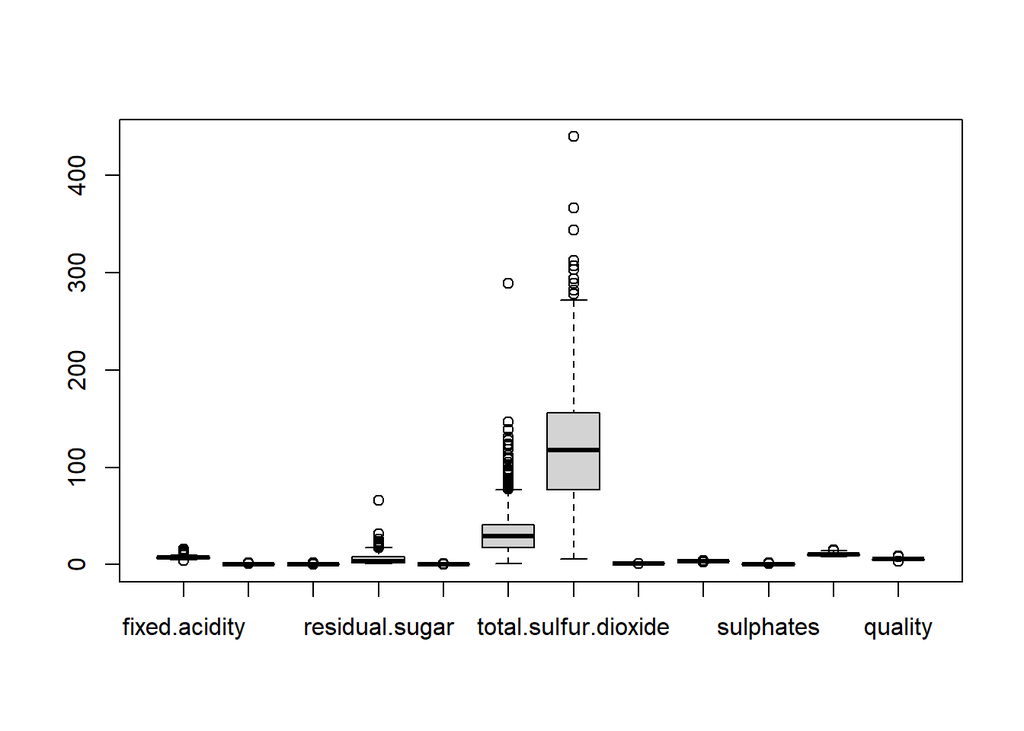

```r
boxplot(wine_data)
```

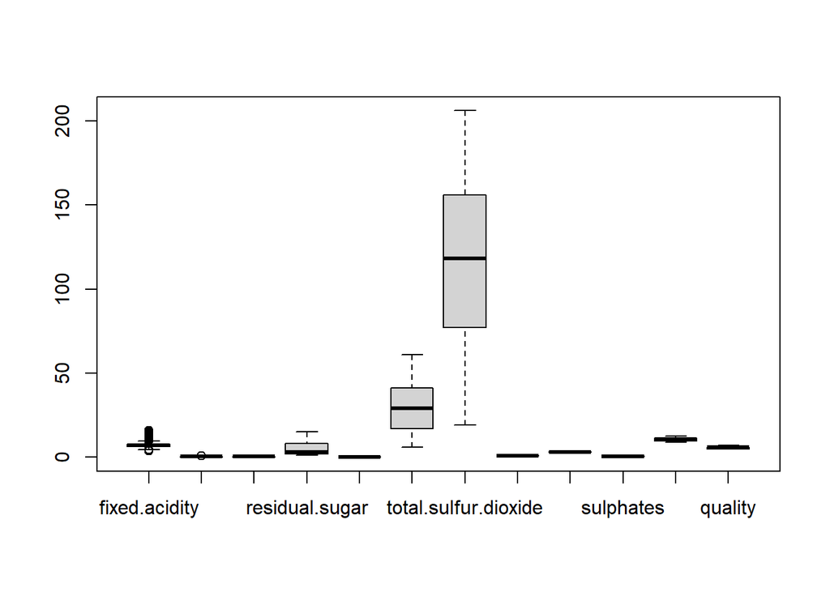

```r
boxplot(wd_capped)
```

```r
wine_data <- wd_capped
```

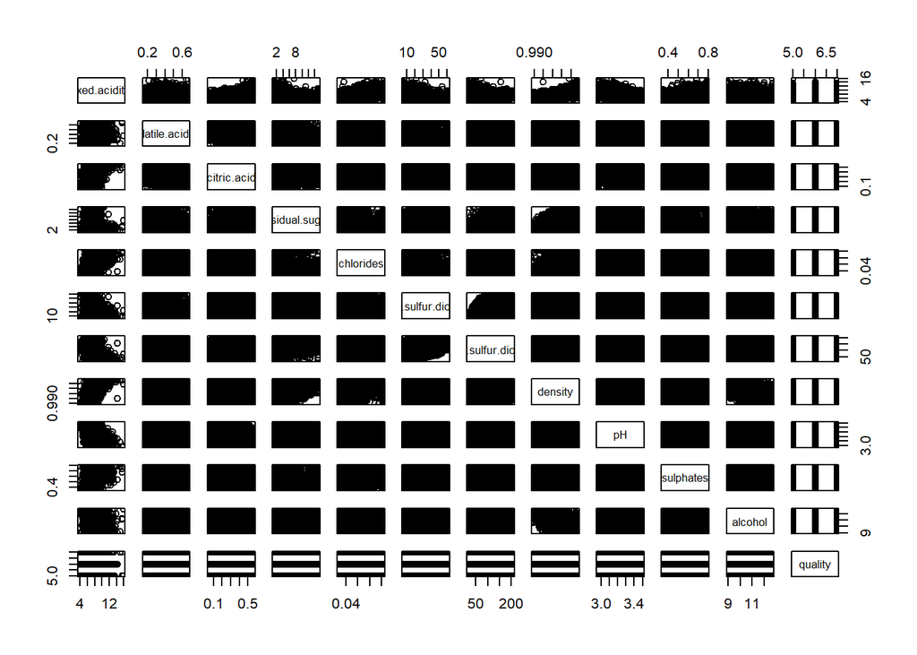

```r
pairs(wine_data)
```

## Summary of the data

```r
summary(wine_data)
```

```
##  fixed.acidity    volatile.acidity  citric.acid    residual.sugar
##  Min.   : 3.800   Min.   :0.1600   Min.   :0.050   Min.   : 1.200
##  1st Qu.: 6.400   1st Qu.:0.2300   1st Qu.:0.250   1st Qu.: 1.800
##  Median : 7.000   Median :0.2900   Median :0.310   Median : 3.000
##  Mean   : 7.215   Mean   :0.3345   Mean   :0.315   Mean   : 5.334
##  3rd Qu.: 7.700   3rd Qu.:0.4000   3rd Qu.:0.390   3rd Qu.: 8.100
##  Max.   :15.900   Max.   :0.6700   Max.   :0.560   Max.   :15.000
##    chlorides       free.sulfur.dioxide total.sulfur.dioxide    density
##  Min.   :0.02800   Min.   : 6.00       Min.   : 19          Min.   :0.9899
##  1st Qu.:0.03800   1st Qu.:17.00       1st Qu.: 77          1st Qu.:0.9923
##  Median :0.04700   Median :29.00       Median :118          Median :0.9949
##  Mean   :0.05327   Mean   :30.03       Mean   :115          Mean   :0.9947
##  3rd Qu.:0.06500   3rd Qu.:41.00       3rd Qu.:156          3rd Qu.:0.9970
##  Max.   :0.10200   Max.   :61.00       Max.   :206          Max.   :0.9994
##        pH          sulphates         alcohol         quality
##  Min.   :2.970   Min.   :0.3500   Min.   : 9.00   Min.   :5.00
##  1st Qu.:3.110   1st Qu.:0.4300   1st Qu.: 9.50   1st Qu.:5.00
##  Median :3.210   Median :0.5100   Median :10.30   Median :6.00
##  Mean   :3.217   Mean   :0.5257   Mean   :10.48   Mean   :5.83
##  3rd Qu.:3.320   3rd Qu.:0.6000   3rd Qu.:11.30   3rd Qu.:6.00
##  Max.   :3.500   Max.   :0.7900   Max.   :12.70   Max.   :7.00
```

# Removal of outliers (Interquartile range)

To begin, we must first identify the outliers in a dataset; typically, two methods are available. 1. z-scores 2. interquartile range

## z-score method

The z-score indicates the number of standard deviations a given value deviates from the mean. A z-score is calculated using the following formula:

$$z = (X – \mu) / \sigma$$
where:

$X$ is a single raw data value

$\mu$ is the population mean

$\sigma$ is the population standard deviation

If an observation’s z-score is less than -3 or larger than 3, it’s considered an outlier.

We implement this method below:

```r
z_scores <- as.data.frame(sapply(wine_data, function(wine_data) (abs(wine_data-mean(wine_data))/sd(wine_data))))
no_outliers <- z_scores[!rowSums(z_scores>3), ]
# head(no_outliers)
dim(wine_data)
```

```
## [1] 6497   12
```

```r
dim(no_outliers)
```

```
## [1] 6369   12
```

```r
dim(wine_data)[1] - dim(no_outliers)[1]
```

```
## [1] 128
```

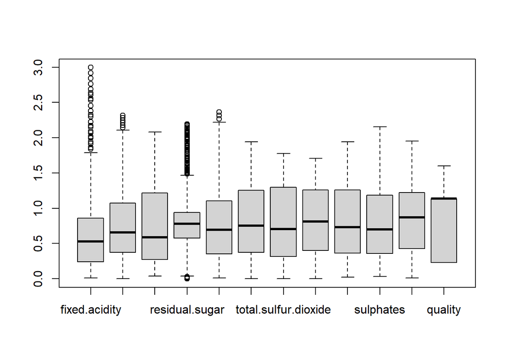

```r
boxplot(no_outliers)
```

## Interquartile range method

In a dataset, it is the difference between the 75th percentile (Q3) and the 25th percentile (Q1).

The interquartile range (IQR) is a measurement of the spread of values in the middle 50%.

If an observation is 1.5 times the interquartile range more than the third quartile (Q3) or 1.5 times the interquartile range less than the first quartile (Q1), it is considered an outlier (Q1).

```r
varlist <- names(wine_data)
# varlist <- varlist[-length(varlist)]

for (i in varlist) {
    var <- eval(parse(text = paste0("wine_data$", i)))
    Q1 <- quantile(var, 0.25)
    Q3 <- quantile(var, 0.75)
    iqr <- IQR(var)
    no_outliers <- subset(wine_data, var > (Q1 - 1.5*iqr) & var < (Q3 + 1.5*iqr) )

}

# We compare the dimensions of the dataset before and after outlier removal
dim(wine_data)
```

```
## [1] 6497   12
```

```r
dim(no_outliers)
```

```
## [1] 6497   12
```

```r
dim(wine_data)[1] - dim(no_outliers)[1]
```

```
## [1] 0
```

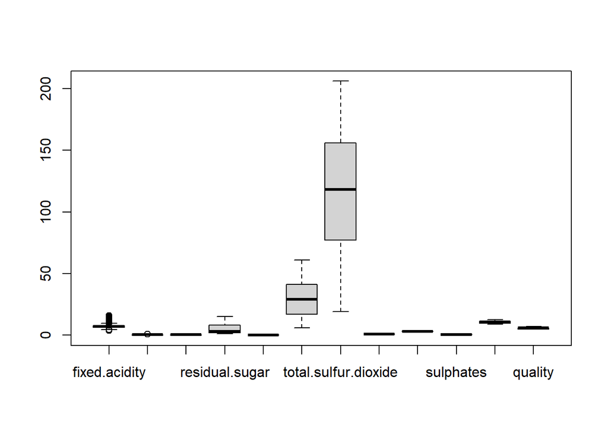

```r
boxplot(no_outliers)
```

We should probably figure out which method we want to use at some point.

# Linear model selection and regularization

## Subset selection methods

### Best Subset Selection

```r
library(leaps)
# Perform best subset selection using the regsubsets() function included
# in the leaps library
regfit.full <- regsubsets(quality ~ ., wine_data, nvmax = 11)

# Summary of the full best subset selection model, the models with 1-11 variables
# are shown below
# shows the best set of variables for each model size
summary(regfit.full)
```

```
## Subset selection object
## Call: regsubsets.formula(quality ~ ., wine_data, nvmax = 11)
## 11 Variables  (and intercept)
##                      Forced in Forced out
## fixed.acidity            FALSE      FALSE
## volatile.acidity         FALSE      FALSE
## citric.acid              FALSE      FALSE
## residual.sugar           FALSE      FALSE
## chlorides                FALSE      FALSE
## free.sulfur.dioxide      FALSE      FALSE
## total.sulfur.dioxide     FALSE      FALSE
## density                  FALSE      FALSE
## pH                       FALSE      FALSE
## sulphates                FALSE      FALSE
## alcohol                  FALSE      FALSE
## 1 subsets of each size up to 11
## Selection Algorithm: exhaustive
##           fixed.acidity volatile.acidity citric.acid residual.sugar chlorides
## 1  ( 1 )  " "           " "              " "         " "            " "
## 2  ( 1 )  " "           "*"              " "         " "            " "
## 3  ( 1 )  " "           "*"              " "         " "            " "
## 4  ( 1 )  " "           "*"              " "         "*"            " "
## 5  ( 1 )  " "           "*"              " "         "*"            " "
## 6  ( 1 )  " "           "*"              " "         "*"            " "
## 7  ( 1 )  " "           "*"              " "         "*"            " "
## 8  ( 1 )  " "           "*"              " "         "*"            " "
## 9  ( 1 )  "*"           "*"              " "         "*"            " "
## 10  ( 1 ) "*"           "*"              "*"         "*"            " "
## 11  ( 1 ) "*"           "*"              "*"         "*"            "*"
##           free.sulfur.dioxide total.sulfur.dioxide density pH  sulphates
## 1  ( 1 )  " "                 " "                  " "     " " " "
## 2  ( 1 )  " "                 " "                  " "     " " " "
## 3  ( 1 )  " "                 " "                  " "     " " "*"
## 4  ( 1 )  " "                 " "                  " "     " " "*"
## 5  ( 1 )  " "                 "*"                  " "     " " "*"
## 6  ( 1 )  "*"                 "*"                  " "     " " "*"
## 7  ( 1 )  "*"                 "*"                  " "     "*" "*"
## 8  ( 1 )  "*"                 "*"                  "*"     "*" "*"
## 9  ( 1 )  "*"                 "*"                  "*"     "*" "*"
## 10  ( 1 ) "*"                 "*"                  "*"     "*" "*"
## 11  ( 1 ) "*"                 "*"                  "*"     "*" "*"
##           alcohol
## 1  ( 1 )  "*"
## 2  ( 1 )  "*"
## 3  ( 1 )  "*"
## 4  ( 1 )  "*"
## 5  ( 1 )  "*"
## 6  ( 1 )  "*"
## 7  ( 1 )  "*"
## 8  ( 1 )  "*"
## 9  ( 1 )  "*"
## 10  ( 1 ) "*"
## 11  ( 1 ) "*"
```

We now check to the different fitting criterion to see which model is best

```r
reg.summary = summary(regfit.full)
```

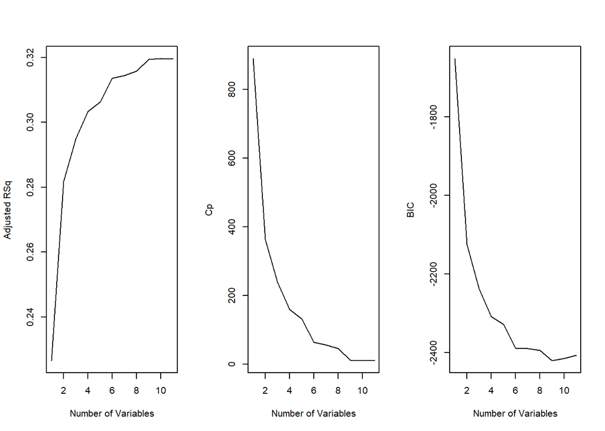

```r
par(mfrow = c(1, 3))
plot(reg.summary$adjr2, xlab = "Number of Variables" ,
ylab = "Adjusted RSq" , type = "l")

plot (reg.summary$cp, xlab = "Number of Variables" ,
ylab = "Cp" , type = "l")

plot (reg.summary$bic, xlab = "Number of Variables" ,
ylab = "BIC" , type = "l")
```

## Find the ideal number of predictors using the different criterion

```r
# Find the number of predictors that corresponds to the maximum adjusted Rsq val
which.max(reg.summary$adjr2)
```

```
## [1] 10
```

```r
# Find the number of predictors that corresponds to the minimum adjusted Cp val
which.min(reg.summary$cp)
```

```
## [1] 10
```

```r
# Find the number of predictors that corresponds to the minimum adjusted BIC val
which.min(reg.summary$bic)
```

```
## [1] 9
```

## Plot which models indicate the smallest statistic

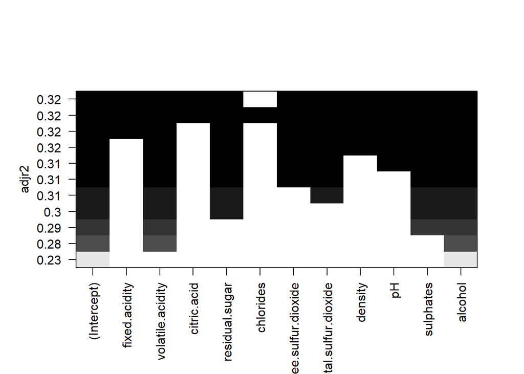

```r
plot(regfit.full, scale = "adjr2")
```

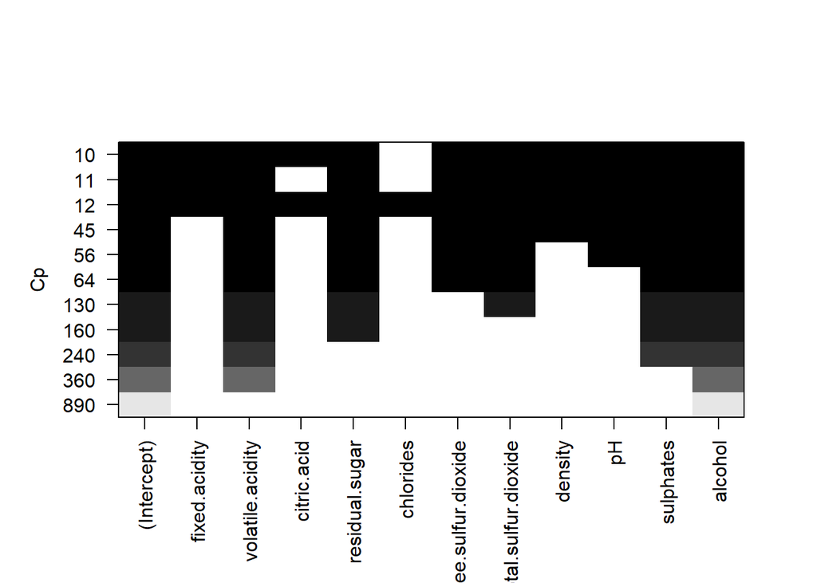

```r
plot(regfit.full, scale = "Cp")
```

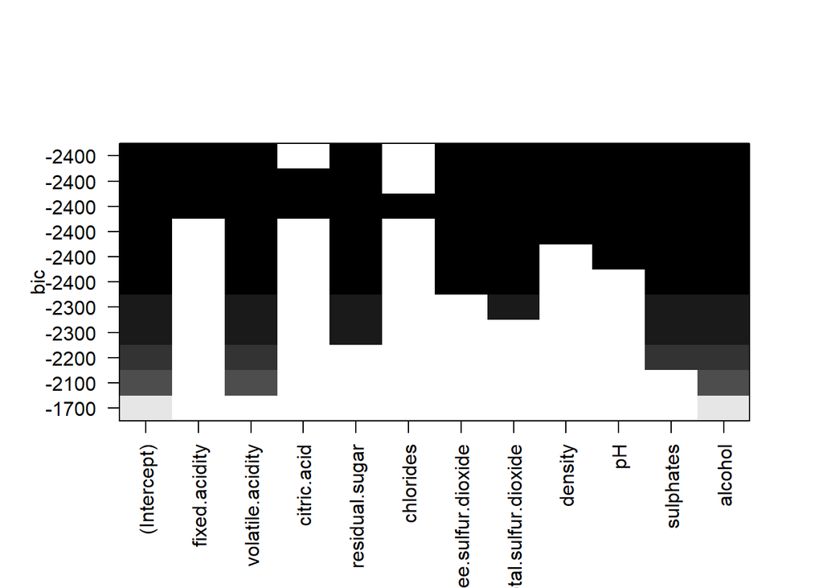

```r
plot(regfit.full, scale = "bic")
```

## Choosing among models using the validation-set approach and cross-validation

### Cross validation

```r
set.seed(1)
train <- sample(c(TRUE, FALSE), nrow(wine_data), replace = TRUE)
test <- (!train)
```

```r
regfit.best <- regsubsets(quality ~ ., data = wine_data[train, ], nvmax = 11)
test.mat <- model.matrix(quality ~ ., data = wine_data[test, ])
```

```r
val.errors <- rep(0, 11)


for (i in 1:11) {
    coefi <- coef(regfit.best, id = i)
    pred <- test.mat[, names(coefi)] %*% coefi
    val.errors[i] <- mean((wine_data$quality[test] - pred)^2)

}
```

```r
val.errors
```

```
##  [1] 0.4148673 0.3828393 0.3746997 0.3705519 0.3691098 0.3655426 0.3650684
##  [8] 0.3639048 0.3616509 0.3616630 0.3618294
```

```r
which.min(val.errors)
```

```
## [1] 9
```

```r
predict.regsubsets <- function(object, newdata, id , ...) {
form <- as.formula(object$call[[2]])
mat <- model.matrix(form, newdata )
coefi <- coef(object, id = id)
xvars <- names (coefi)
mat[, xvars ] %*% coefi
}
```

```r
regfit.best <- regsubsets(quality ~ ., data = wine_data, nvmax = 11)
coef(regfit.best, 10)
```

```
##          (Intercept)        fixed.acidity     volatile.acidity
##         68.960350471          0.074094737         -1.204312818
##          citric.acid       residual.sugar  free.sulfur.dioxide
##         -0.132337321          0.045462743          0.005868213
## total.sulfur.dioxide              density                   pH
##         -0.002382853        -68.228268139          0.504158979
##            sulphates              alcohol
##          0.883924623          0.230180918
```

Must perform best subset selection with each of the k training sets.

```r
k <- 5
n <- nrow(wine_data)
set.seed(1)
folds <- sample(rep(1:k, length = n))
cv.errors <- matrix(NA, k, 11, dimnames = list(NULL, paste(1:11)))
```

```r
for (j in 1:k) {
    best.fit <- regsubsets(quality ~ ., data = wine_data[folds != j, ], nvmax = 11)

    for (i in 1:11) {
        pred <- predict(best.fit, wine_data[folds == j, ], id = i)
        cv.errors[j, i] <- mean((wine_data$quality[folds == j] - pred)^2)
    }
}
```

```r
mean.cv.errors <- apply(cv.errors, 2, mean)
mean.cv.errors
```

```
##         1         2         3         4         5         6         7         8
## 0.4136115 0.3841631 0.3771888 0.3727125 0.3712452 0.3674260 0.3677570 0.3667030
##         9        10        11
## 0.3648552 0.3649498 0.3649542
```

```r
min(mean.cv.errors)
```

```
## [1] 0.3648552
```

We see that cross validation selects a 9 variable model.

We now perform best subset selection on the full data set in order to obtain this model

```r
reg.best <- regsubsets(quality ~ ., data = wine_data, nvmax = 11)
coef(reg.best, 9)
```

```
##          (Intercept)        fixed.acidity     volatile.acidity
##         70.003827333          0.069246882         -1.153656143
##       residual.sugar  free.sulfur.dioxide total.sulfur.dioxide
##          0.045698051          0.005878583         -0.002447426
##              density                   pH            sulphates
##        -69.311834099          0.520147565          0.874475435
##              alcohol
##          0.227325902
```

## Ridge-regression and the lasso

## Ridge-regression

```r
set.seed(1)
x <- model.matrix(quality ~ ., wine_data)[, -1]
y <- wine_data$quality
train <- sample(1:nrow(x), nrow(x)/2)
test <- (-train)
y.test <- y[test]
```

```r
library(glmnet)
grid <- 10^seq(10, -2, length = 100)
```

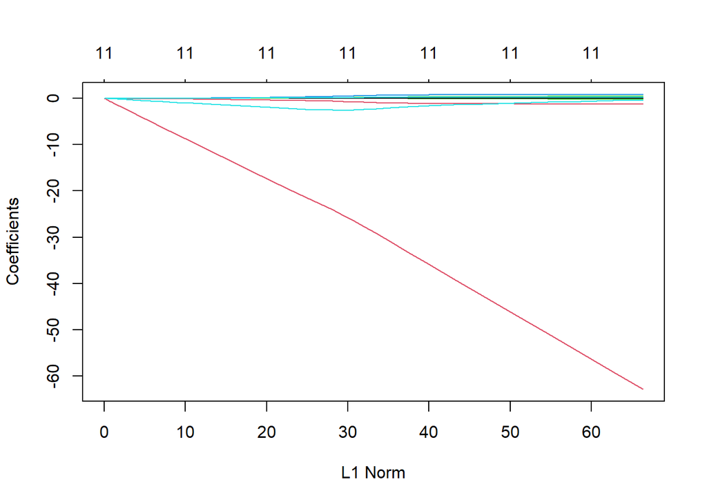

```r
ridge.mod <- glmnet(x[train, ], y[train], alpha = 0, lambda = grid)
plot(ridge.mod)
```

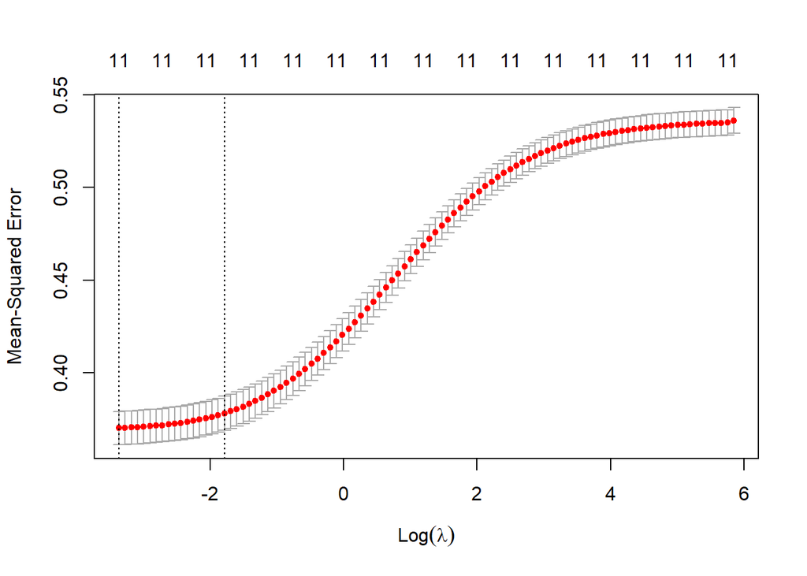

```r
set.seed(1)
cv.out <- cv.glmnet(x[train, ], y[train], alpha = 0)
plot(cv.out)
```

```r
bestlam <- cv.out$lambda.min
lasso.pred <- predict(ridge.mod, s = bestlam, newx = x[test, ])
mean((lasso.pred - y.test)^2)
```

```
## [1] 0.3605988
```

```r
out <- glmnet(x, y, alpha = 0, lambda = grid)
ridge.coef <- predict(out, type = "coefficients", s = bestlam)[1:12, ]
ridge.coef
```

```
##          (Intercept)        fixed.acidity     volatile.acidity
##         40.934526532          0.043956261         -1.134589970
##          citric.acid       residual.sugar            chlorides
##         -0.062270550          0.030537484         -1.173505845
##  free.sulfur.dioxide total.sulfur.dioxide              density
##          0.005148968         -0.002015011        -39.330410551
##                   pH            sulphates              alcohol
##          0.345771173          0.785362246          0.243205550
```

```r
ridge.coef[ridge.coef != 0]
```

```
##          (Intercept)        fixed.acidity     volatile.acidity
##         40.934526532          0.043956261         -1.134589970
##          citric.acid       residual.sugar            chlorides
##         -0.062270550          0.030537484         -1.173505845
##  free.sulfur.dioxide total.sulfur.dioxide              density
##          0.005148968         -0.002015011        -39.330410551
##                   pH            sulphates              alcohol
##          0.345771173          0.785362246          0.243205550
```

## The lasso

```r
set.seed(1)
x <- model.matrix(quality ~ ., wine_data)[, -1]
y <- wine_data$quality
train <- sample(1:nrow(x), nrow(x)/2)
test <- (-train)
y.test <- y[test]
```

```r
library(glmnet)
grid <- 10^seq(10, -2, length = 100)
```

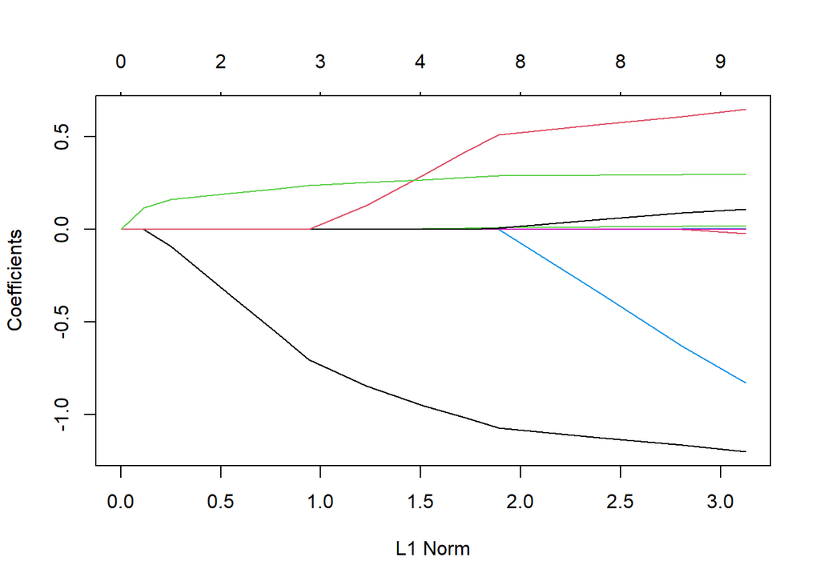

```r
lasso.mod <- glmnet(x[train, ], y[train], alpha = 1, lambda = grid)
plot(lasso.mod)
```

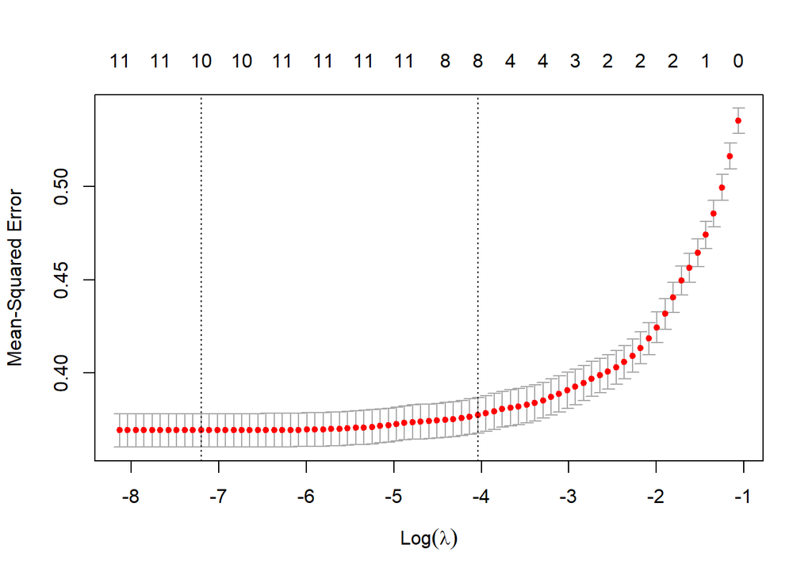

```r
set.seed(1)
cv.out <- cv.glmnet(x[train, ], y[train], alpha = 1)
plot(cv.out)
```

```r
bestlam <- cv.out$lambda.min
lasso.pred <- predict(lasso.mod, s = bestlam, newx = x[test, ])
mean((lasso.pred - y.test)^2)
```

```
## [1] 0.3631217
```

```r
out <- glmnet(x, y, alpha = 1, lambda = grid)
lasso.coef <- predict(out, type = "coefficients", s = bestlam)[1:12, ]
lasso.coef
```

```
##          (Intercept)        fixed.acidity     volatile.acidity
##          2.474306957          0.000000000         -1.189634457
##          citric.acid       residual.sugar            chlorides
##          0.000000000          0.014669290         -0.754664550
##  free.sulfur.dioxide total.sulfur.dioxide              density
##          0.003832357         -0.001368393          0.000000000
##                   pH            sulphates              alcohol
##          0.093997115          0.634427372          0.297747749
```

```r
lasso.coef[lasso.coef != 0]
```

```
##          (Intercept)     volatile.acidity       residual.sugar
##          2.474306957         -1.189634457          0.014669290
##            chlorides  free.sulfur.dioxide total.sulfur.dioxide
##         -0.754664550          0.003832357         -0.001368393
##                   pH            sulphates              alcohol
##          0.093997115          0.634427372          0.297747749
```

```r
lasso.coef[lasso.coef == 0]
```

```
## fixed.acidity   citric.acid       density
##             0             0             0
```

## Princpal components regression

```r
set.seed(1)
x <- model.matrix(quality ~ ., wine_data)[, -1]
y <- wine_data$quality
train <- sample(1:nrow(x), nrow(x)/2)
test <- (-train)
y.test <- y[test]
```

```r
library(pls)
set.seed(2)
pcr.fit <- pcr(quality ~ ., data = wine_data, scale = TRUE, validation = "CV")
```

```r
summary(pcr.fit)
```

```
## Data:    X dimension: 6497 11
##  Y dimension: 6497 1
## Fit method: svdpc
## Number of components considered: 11
##
## VALIDATION: RMSEP
## Cross-validated using 10 random segments.
##        (Intercept)  1 comps  2 comps  3 comps  4 comps  5 comps  6 comps
## CV          0.7312   0.7252   0.6807   0.6651   0.6478   0.6327   0.6246
## adjCV       0.7312   0.7252   0.6807   0.6651   0.6477   0.6327   0.6245
##        7 comps  8 comps  9 comps  10 comps  11 comps
## CV      0.6243   0.6238   0.6045    0.6047    0.6038
## adjCV   0.6242   0.6238   0.6045    0.6046    0.6038
##
## TRAINING: % variance explained
##          1 comps  2 comps  3 comps  4 comps  5 comps  6 comps  7 comps  8 comps
## X         30.154    53.23    67.55    76.24    81.72    87.12    91.63    94.88
## quality    1.628    13.39    17.34    21.61    25.23    27.18    27.28    27.41
##          9 comps  10 comps  11 comps
## X          97.81     99.71    100.00
## quality    31.86     31.86     32.07
```

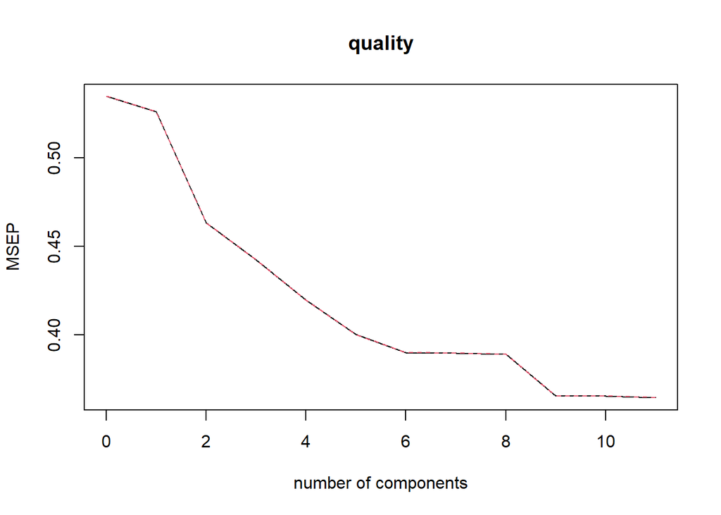

```r
validationplot(pcr.fit, val.type = "MSEP")
```

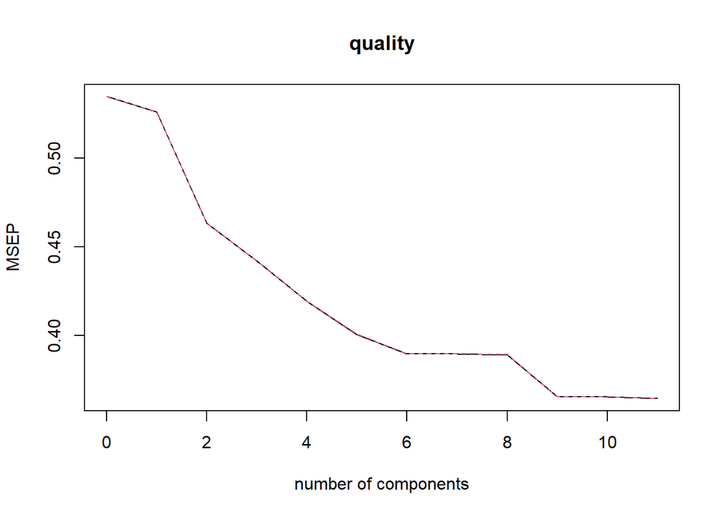

```r
set.seed(1)
pcr.fit <- pcr(quality ~ ., data = wine_data, scale = TRUE, validation = "CV")
validationplot(pcr.fit, val.type = "MSEP")
```

```r
pcr.pred <- predict(pcr.fit, x[test, ], ncomp = 5)
mean((pcr.pred - y.test)^2)
```

```
## [1] 0.3942515
```

```r
pcr.fit <- pcr(y ~ x, scale = TRUE, ncomp = 5)
summary(pcr.fit)
```

```
## Data:    X dimension: 6497 11
##  Y dimension: 6497 1
## Fit method: svdpc
## Number of components considered: 5
## TRAINING: % variance explained
##    1 comps  2 comps  3 comps  4 comps  5 comps
## X   30.154    53.23    67.55    76.24    81.72
## y    1.628    13.39    17.34    21.61    25.23
```

## Partial least squares

```r
set.seed(1)
x <- model.matrix(quality ~ ., wine_data)[, -1]
y <- wine_data$quality
train <- sample(1:nrow(x), nrow(x)/2)
test <- (-train)
y.test <- y[test]
```

```r
pls.fit <- plsr(quality ~ ., data = wine_data, subset = train, scale = TRUE, validation = "CV")
summary(pls.fit)
```

```
## Data:    X dimension: 3248 11
##  Y dimension: 3248 1
## Fit method: kernelpls
## Number of components considered: 11
##
## VALIDATION: RMSEP
## Cross-validated using 10 random segments.
##        (Intercept)  1 comps  2 comps  3 comps  4 comps  5 comps  6 comps
## CV          0.7323   0.6456   0.6211   0.6130   0.6096   0.6083   0.6080
## adjCV       0.7323   0.6456   0.6211   0.6129   0.6095   0.6082   0.6079
##        7 comps  8 comps  9 comps  10 comps  11 comps
## CV      0.6072   0.6072   0.6072    0.6072    0.6072
## adjCV   0.6071   0.6071   0.6071    0.6071    0.6071
##
## TRAINING: % variance explained
##          1 comps  2 comps  3 comps  4 comps  5 comps  6 comps  7 comps  8 comps
## X          22.67    38.37    58.38    70.97    78.71    84.36    84.86    88.20
## quality    22.46    28.36    30.26    31.07    31.37    31.44    31.66    31.66
##          9 comps  10 comps  11 comps
## X          91.91     96.16    100.00
## quality    31.66     31.66     31.66
```

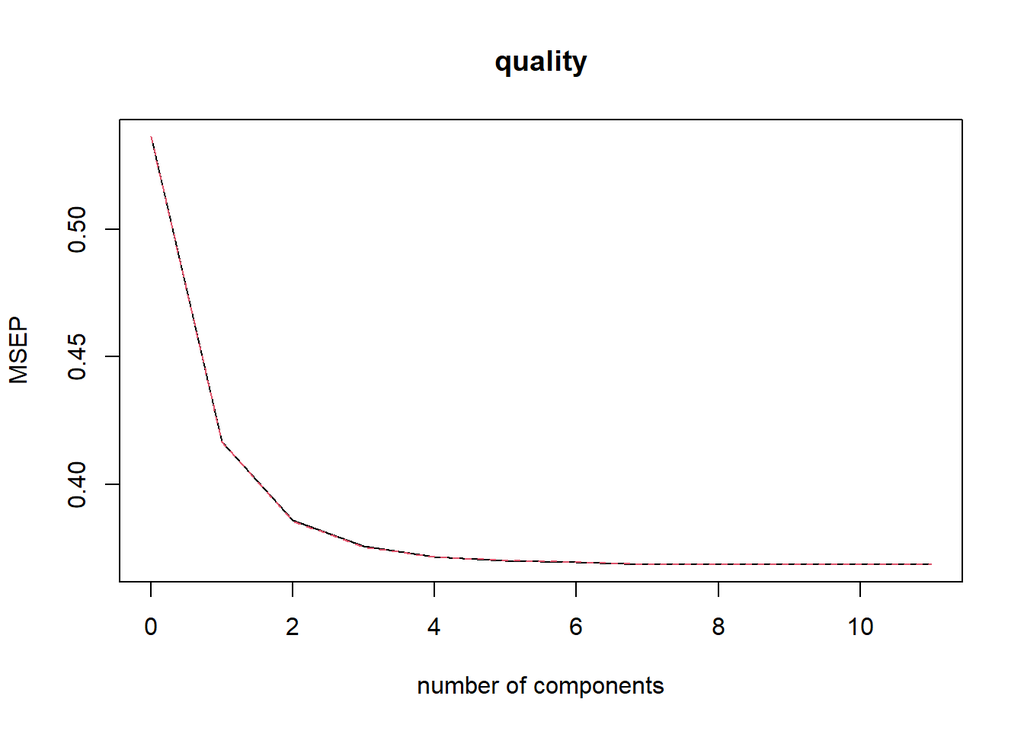

```r
validationplot(pls.fit, val.type = "MSEP")
```

```r
pls.pred <- predict(pls.fit, x[test, ], ncomp = 1)
mean((pls.pred - y.test)^2)
```

```
## [1] 0.4068395
```

```r
pls.fit <- plsr(quality ~ ., data = wine_data, scale = TRUE, ncomp = 1)
summary(pls.fit)
```

```
## Data:    X dimension: 6497 11
##  Y dimension: 6497 1
## Fit method: kernelpls
## Number of components considered: 1
## TRAINING: % variance explained
##          1 comps
## X          22.53
## quality    23.15
```